# CH4_Exercises

Ben Jones

30 March 2019

```r
library(rethinking)
```

*4E1 The first line is the likelihood, the lower two are the priors

*4E2 Two parameters, $\mu$ and $\sigma$

*4E3
$$P(\mu, \sigma|y_i) = \frac{\prod_i N(y_i|\mu, sigma) N(\mu|0,10) \mbox{Unif}(\sigma|0,10)}{\int \int \prod_i N(y_i|\mu, sigma) N(\mu|0,10) \mbox{Unif}(\sigma|0,10) d\mu d\sigma }$$

*4E4 The second line is the linear model, describing the relationship between $y$ and $x$

*4E5 There are three parameters, $\alpha$, $\beta$ and $\sigma$

*4M1 Simulate from $\mu$ and $\sigma$, and subsequently from $y$

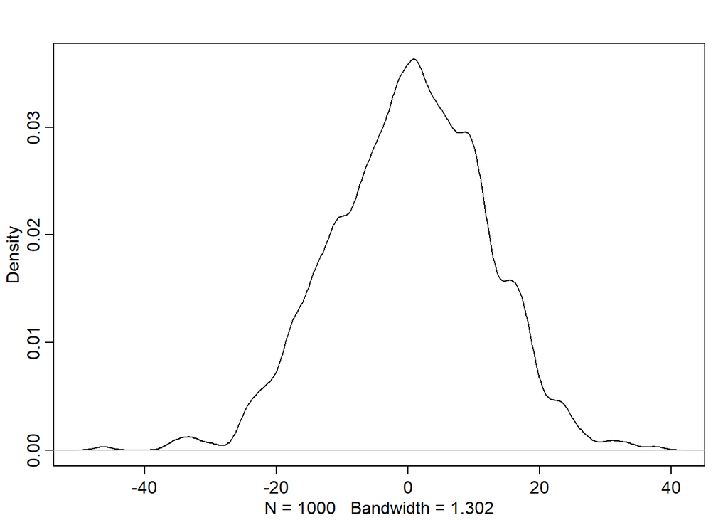

```r
mu <- rnorm(1000,0,10)
sigma <- runif(1000, 0, 10)
y <- rnorm(1000, mu, sigma)
dens(y)
```

*4M2

```r
model <-  alist(
    y ~ dnorm(mu, sigma),
    mu ~ dnorm(0, 10),
    sigma ~ dunif(0, 10)
)
```

*4M3
$$y_i \sim \mbox{Normal}(\mu_i,\sigma) \\
\mu_i = \alpha + \beta x_i \\
\alpha \sim \mbox{Normal}(0, 50) \\
\sigma \sim \mbox{Uniform}(0, 50)$$

*4M4 Let $y_i$ denote height and $x_i$ denote year. Then the model is
$$y_i \sim \mbox{Normal}(\mu_i, \sigma) \\
\sigma = \alpha + \beta x_i \\
\alpha \sim \mbox{Normal}(0,200) \\
\beta \sim \mbox{Normal}(10,50)\\
\sigma \sim \mbox{Uniform(0,50)}$$
We Do not know anything about the age of students - they could be university students or primary school kids. Therefore we set a prior for alpha, which is height at year 0, as very wide but necessarily positive. We set a wide prior for $\beta$ as we don’t know anything about the influence of time on height, but make it positive as we expect it to increase.

*4M5 Yes, we would centre alpha at 120 and reduce the SD to reflect the additional certainty. We would leave the mean of $\beta$ the same as we have already specidied it as positive, but would reduce the SD to reflect the uncertainty. We would leave $\sigma$ unchanged as we still do not know how much variability there is in the heights.

*4M6 I would set the upper limit of the $\sigma$ uniform prior to 64 to reflect this additional knowledge.

*4H1

```r
data(Howell1)
data <- Howell1
model <-  map(
  alist(
    height ~ dnorm(mu, sigma),
    mu <- alpha + beta*weight,
    alpha ~ dnorm(0,200),
    beta ~ dnorm(10,50),
    sigma ~ dunif(0, 200)
  ),
  data = data
)
model
```

```
##
## Maximum a posteriori (MAP) model fit
##
## Formula:
## height ~ dnorm(mu, sigma)
## mu <- alpha + beta * weight
## alpha ~ dnorm(0, 200)
## beta ~ dnorm(10, 50)
## sigma ~ dunif(0, 200)
##
## MAP values:
##     alpha      beta     sigma
## 75.433734  1.764349  9.345880
##
## Log-likelihood: -1987.71
```

We now have the best parameter estimates for the model. Saving new weights as a vector and using the link function will allow us to estimate heights based on these.

```r
weight_new <- c(46.95,43.72, 64.78, 32.59,54.63)
predictions <- link(model, data = data.frame(weight = weight_new))
```

```
## [ 100 / 1000 ]
[ 200 / 1000 ]
[ 300 / 1000 ]
[ 400 / 1000 ]
[ 500 / 1000 ]
[ 600 / 1000 ]
[ 700 / 1000 ]
[ 800 / 1000 ]
[ 900 / 1000 ]
[ 1000 / 1000 ]
```

```r
expected <- apply(predictions,  2, mean)
HPDI <- apply(predictions, 2, HPDI, prob = 0.89)
expected
```

```
## [1] 158.2547 152.5547 189.7197 132.9133 171.8078
```

```r
HPDI
```

```
##           [,1]     [,2]     [,3]     [,4]     [,5]
## |0.89 157.4498 151.7732 188.4210 132.2127 170.8655
## 0.89| 159.0354 153.2140 191.1462 133.5383 172.8534
```

```r
data.frame(Individual = 1:5,
           Weight = weight_new,
           expected = expected,
           Lower = HPDI[1,],
           Higher = HPDI[2,] )
```

```
##   Individual Weight expected    Lower   Higher
## 1          1  46.95 158.2547 157.4498 159.0354
## 2          2  43.72 152.5547 151.7732 153.2140
## 3          3  64.78 189.7197 188.4210 191.1462
## 4          4  32.59 132.9133 132.2127 133.5383
## 5          5  54.63 171.8078 170.8655 172.8534
```

*4H2 Extract only data below 18 years.

```r
data2 <- data[data$age < 18,]
```

```r
model2 <-  map(
  alist(
    height ~ dnorm(mu, sigma),
    mu <- alpha + beta*weight,
    alpha ~ dnorm(0,200),
    beta ~ dnorm(10,50),
    sigma ~ dunif(0, 200)
  ),
  data = data2
)
precis(model2)
```

```
##        Mean StdDev  5.5% 94.5%
## alpha 58.23   1.40 55.99 60.46
## beta   2.72   0.07  2.61  2.83
## sigma  8.44   0.43  7.75  9.13
```

The model predicts a $\beta$ of 2.72, (89% HPDI: 2.61,2.83) suggesting that a one unit increase in weight will result in a 2.72 increase in height. So an increase of 10 units in weight will result in an expected increase in height of 27.2cm. The estimate of $\sigma$ suggests that the standard deviation of heights is 8.44.

2. We plot the data along with the regression line and 89% HPDI.

```r
weight.seq <- seq(min(data2$weight),max(data2$weight), by = 0.5)
mu <- link(model2,data = data.frame(weight = weight.seq))
```

```
## [ 100 / 1000 ]
[ 200 / 1000 ]
[ 300 / 1000 ]
[ 400 / 1000 ]
[ 500 / 1000 ]
[ 600 / 1000 ]
[ 700 / 1000 ]
[ 800 / 1000 ]
[ 900 / 1000 ]
[ 1000 / 1000 ]
```

```r
mu.mean <- apply(mu, 2, mean)
mu.HPDI <- apply(mu, 2, HPDI, prob = 0.89)
plot(height~weight, data = data2)
lines(weight.seq,mu.mean)
shade(mu.HPDI,weight.seq)
sim.height <- sim(model2, data = list(weight = weight.seq), n=1e4)
```

```
## [ 1000 / 10000 ]
[ 2000 / 10000 ]
[ 3000 / 10000 ]
[ 4000 / 10000 ]
[ 5000 / 10000 ]
[ 6000 / 10000 ]
[ 7000 / 10000 ]
[ 8000 / 10000 ]
[ 9000 / 10000 ]
[ 10000 / 10000 ]
```

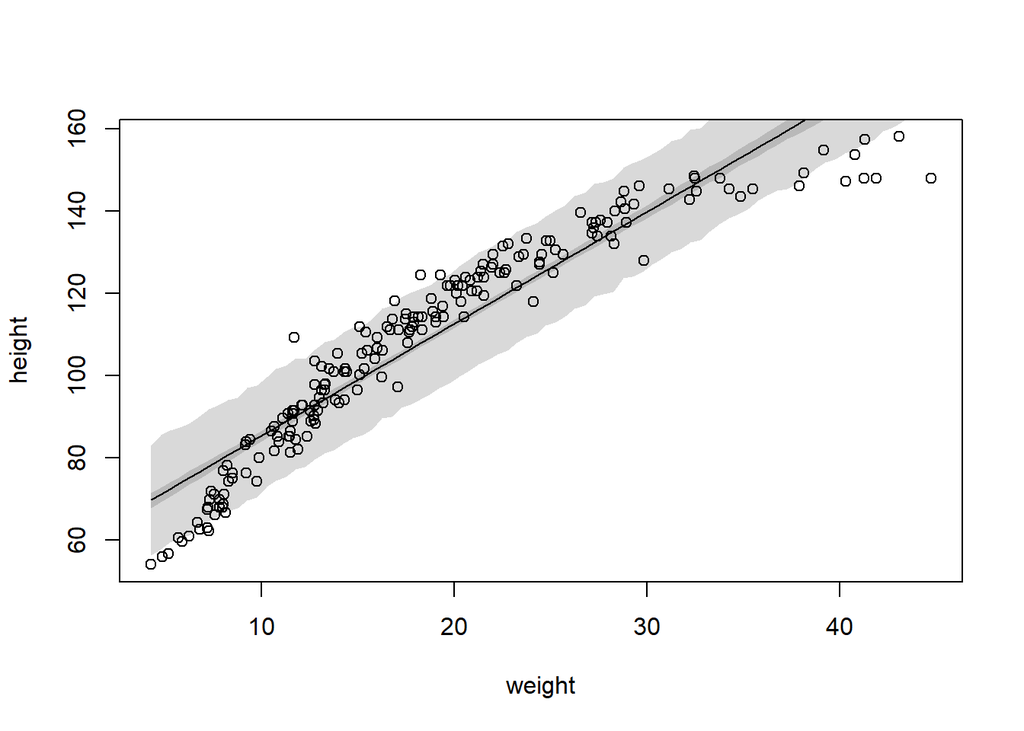

```r
HPDI.height <- apply(sim.height, 2, HPDI, prob = 0.89)
shade(HPDI.height, weight.seq)
```

3. The relationship between height and weight does not appear to be linear. Further, at upper and lower weights the model does not appear to be predicting height very well, with some data points falling outside of the 89% HPDI. A better model may be polynomial of order two, although this creates difficulty with interpretation.

*4H3

```r
model3 <-  map(
  alist(
    height ~ dnorm(mu, sigma),
    mu <- alpha + beta*log(weight),
    alpha ~ dnorm(178,100),
    beta ~ dnorm(0,100),
    sigma ~ dunif(0, 50)
  ),
  data = data
)
precis(model3)
```

```
##         Mean StdDev   5.5%  94.5%
## alpha -23.78   1.34 -25.92 -21.65
## beta   47.08   0.38  46.46  47.69
## sigma   5.13   0.16   4.89   5.38
```

This suggests that a unit increase in log weight will increase height by 47.08.

```r
weight.seq <- seq(min(data$weight),max(data$weight),by=0.5)
mu <- link(model3,data = data.frame(weight = weight.seq))
```

```
## [ 100 / 1000 ]
[ 200 / 1000 ]
[ 300 / 1000 ]
[ 400 / 1000 ]
[ 500 / 1000 ]
[ 600 / 1000 ]
[ 700 / 1000 ]
[ 800 / 1000 ]
[ 900 / 1000 ]
[ 1000 / 1000 ]
```

```r
mu.mean <- apply(mu, 2, mean)
mu.HPDI <- apply(mu, 2, HPDI, prob = 0.97)
plot(height~weight, data = data, col = col.alpha(rangi2,0.4))
lines(weight.seq,mu.mean)
shade(mu.HPDI,weight.seq)
sim.height <- sim(model3, data = list(weight = weight.seq), n=1e4)
```

```
## [ 1000 / 10000 ]
[ 2000 / 10000 ]
[ 3000 / 10000 ]
[ 4000 / 10000 ]
[ 5000 / 10000 ]
[ 6000 / 10000 ]
[ 7000 / 10000 ]
[ 8000 / 10000 ]
[ 9000 / 10000 ]
[ 10000 / 10000 ]
```

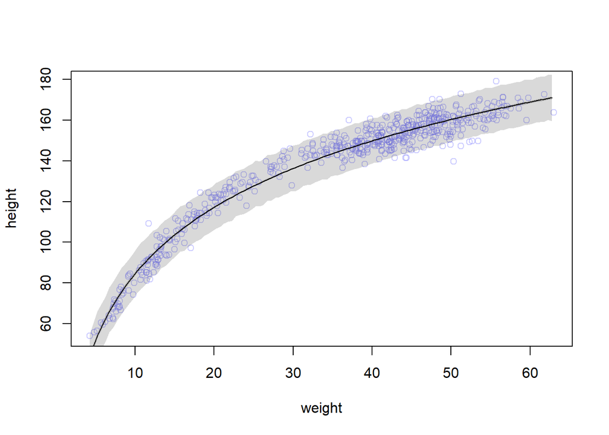

```r
HPDI.height <- apply(sim.height, 2, HPDI, prob = 0.97)
shade(HPDI.height, weight.seq)
```

This model appears to better fit the data.